# ![:scale 9%](images/Rlogo.svg) Tools for a Code-based Data Workflow

## `skimr::skim`

```r
skimr::skim(mammals)
```

Data summary

| Name | mammals |
| --- | --- |
| Number of rows | 2943 |
| Number of columns | 9 |
| _______________________ |  |
| Column type frequency: |  |
| character | 2 |
| numeric | 7 |
| ________________________ |  |
| Group variables | None |

**Variable type: character**

| skim_variable | n_missing | complete_rate | min | max | empty | n_unique | whitespace |
| --- | --- | --- | --- | --- | --- | --- | --- |
| species_id | 63 | 0.98 | 2 | 2 | 0 | 30 | 0 |
| sex | 204 | 0.93 | 1 | 1 | 0 | 2 | 0 |

**Variable type: numeric**

| skim_variable | n_missing | complete_rate | mean | sd | p0 | p25 | p50 | p75 | p100 | hist |
| --- | --- | --- | --- | --- | --- | --- | --- | --- | --- | --- |
| record_id | 0 | 1.00 | 17754.05 | 10328.17 | 15 | 8630.5 | 17929 | 26794 | 35541 | ▇▇▇▇▇ |
| month | 0 | 1.00 | 6.50 | 3.38 | 1 | 4.0 | 7 | 9 | 12 | ▇▆▆▅▇ |
| day | 0 | 1.00 | 15.90 | 8.16 | 1 | 9.0 | 15 | 23 | 31 | ▆▇▇▇▅ |
| year | 0 | 1.00 | 1990.46 | 7.54 | 1977 | 1983.0 | 1990 | 1997 | 2002 | ▇▆▆▆▇ |
| plot_id | 0 | 1.00 | 11.49 | 6.79 | 1 | 5.0 | 11 | 17 | 24 | ▇▆▇▆▅ |
| hindfoot_length | 348 | 0.88 | 29.40 | 9.64 | 11 | 21.0 | 31 | 36 | 70 | ▇▅▇▂▁ |
| weight | 274 | 0.91 | 43.40 | 38.28 | 4 | 20.0 | 36 | 48 | 280 | ▇▁▁▁▁ |

## `DataExplorer::create_report`

```r
# An .html file is output to your current working directory and opens in browser
DataExplorer::create_report(mammals,
                            output_file = "mammal_data_profile.html")
```

### Basic Statistics

#### Raw Counts

| Name | Value |
| --- | --- |
| Rows | 2,943 |
| Columns | 9 |
| Discrete columns | 2 |
| Continuous columns | 7 |
| All missing columns | 0 |
| Missing observations | 889 |
| Complete Rows | 2,527 |
| Total observations | 26,487 |
| Memory allocation | 131 Kb |

#### Percentages

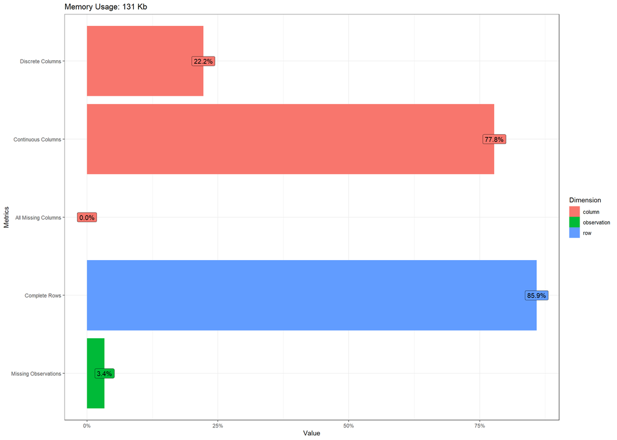

### Missing Data Profile

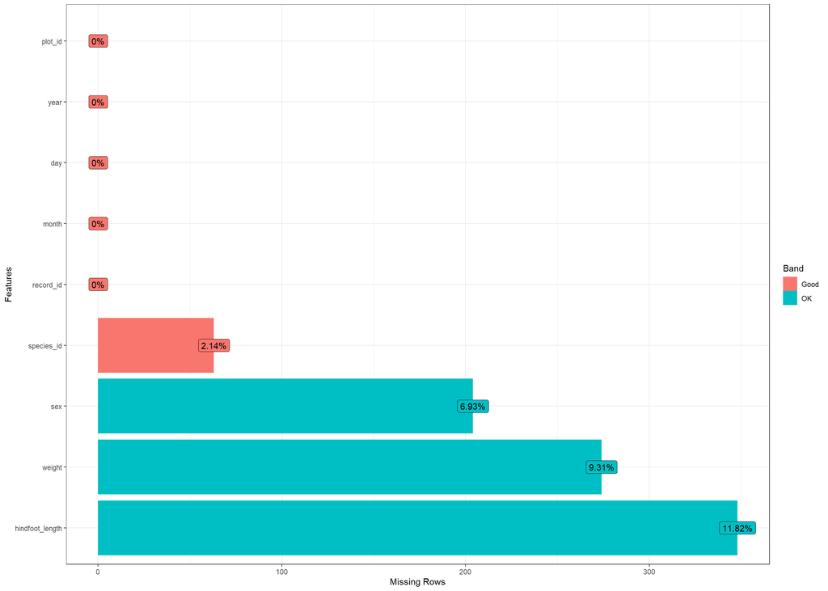

### Univariate Distribution

#### Histogram

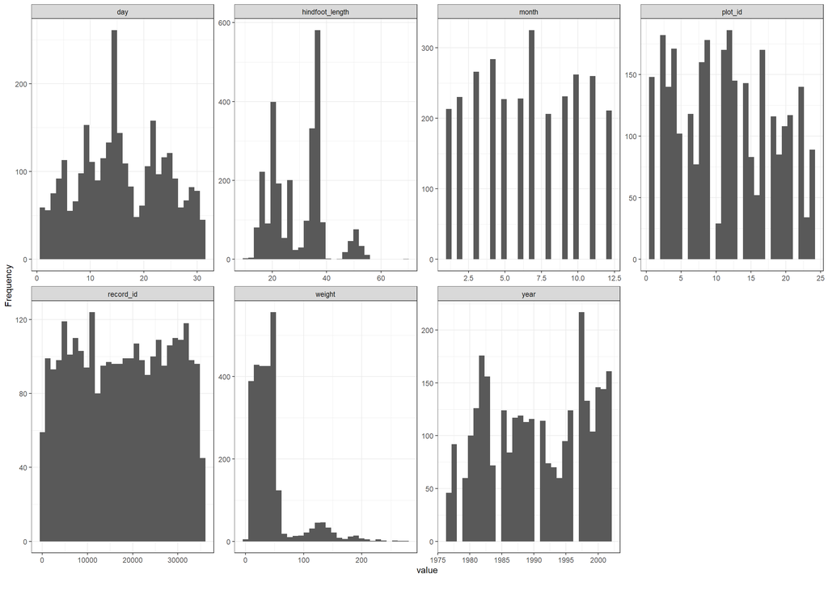

#### Bar Chart (by frequency)

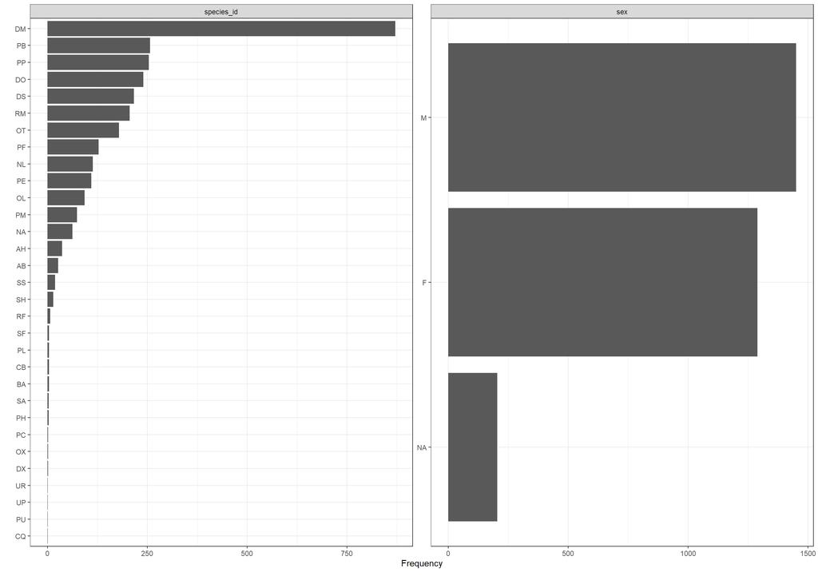

#### QQ Plot

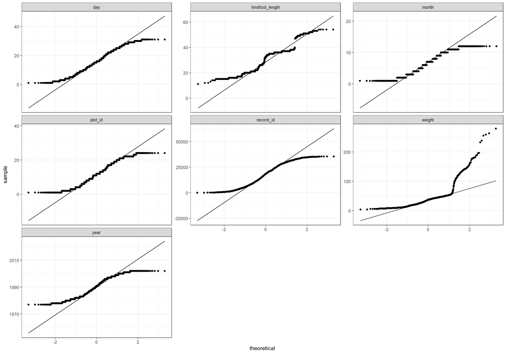

### Correlation Analysis

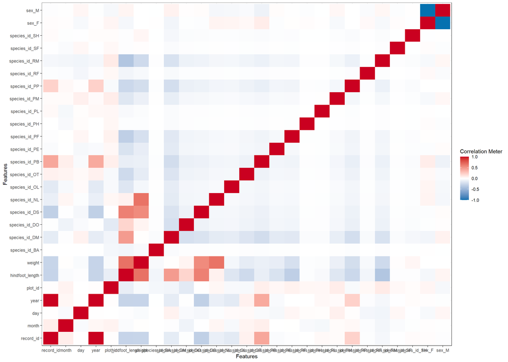

# Assertive programming

- [`assertr`](https://cran.r-project.org/web/packages/assertr/index.html) ([vignette](https://cran.r-project.org/web/packages/assertr/vignettes/assertr.html))

```r
# Expect maximum weight
mammals %>%
  assertr::verify(weight < 100)

# Alternative, giving weight range
mammals %>%
  assertr::assert(assertr::within_bounds(15, 100), weight)

# Confirm expected format of sex variable
mammals %>%
  assertr::assert(assertr::in_set(c("M", "F")), sex)
```

[figure not shown]

# Exploratory data analysis

- Aims for understanding
  - variation, missing values, covariation

- Iterative (questions -> answers -> questions)

- Visualization is key

[figure not shown]

# Visualization framework

- [`ggplot2`](https://cran.r-project.org/web/packages/ggplot2/index.html)

- "grammar of graphics"

- flexible, consistent

[figure not shown]

### Target: *Submerged aquatic vegetation - Mattamuskeet NWR*

[figure not shown]

```r
ggplot(data = sav_model_fit)
```

[figure not shown]

```r
ggplot(data = sav_model_fit) +
* geom_raster(aes(x = x, y = y, fill = sav))
```

[figure not shown]

```r
ggplot(data = sav_model_fit) +
  geom_raster(aes(x = x, y = y, fill = sav)) +
* geom_sf(data = LM, color = "black", fill = NA)
```

[figure not shown]

```r
ggplot(data = sav_model_fit) +
  geom_raster(aes(x = x, y = y, fill = sav)) +
  geom_sf(data = LM, color = "black", fill = NA) +
* geom_point(data = sav_pts, shape = 21,
*            aes(x, y, fill = sav))
```

[figure not shown]

```r
ggplot(data = sav_model_fit) +
  geom_raster(aes(x = x, y = y, fill = sav)) +
  geom_sf(data = LM, color = "black", fill = NA) +
  geom_point(data = sav_pts, shape = 21,
             aes(x, y, fill = sav)) +
* scale_fill_viridis_c("Proportion\nSAV",
*                    breaks = c(0,0.1,0.4,0.7,1),
*                    limits = c(0,1))
```

[figure not shown]

```r
ggplot(data = sav_model_fit) +
  geom_raster(aes(x = x, y = y, fill = sav)) +
  geom_sf(data = LM, color = "black", fill = NA) +
  geom_point(data = sav_pts, shape = 21,
             aes(x, y, fill = sav)) +
  scale_fill_viridis_c("Proportion\nSAV",
                     breaks = c(0,0.1,0.4,0.7,1),
                     limits = c(0,1)) +
* coord_sf()
```

[figure not shown]

```r
ggplot(data = sav_model_fit) +
  geom_raster(aes(x = x, y = y, fill = sav)) +
  geom_sf(data = LM, color = "black", fill = NA) +
  geom_point(data = sav_pts, shape = 21,
             aes(x, y, fill = sav)) +
  scale_fill_viridis_c("Proportion\nSAV",
                     breaks = c(0,0.1,0.4,0.7,1),
                     limits = c(0,1)) +
  coord_sf() +
* labs(title = "SAV in Lake Mattamuskeet",
*      subtitle = "2004",
*      x = NULL, y = NULL)
```

[figure not shown]

```r
ggplot(data = sav_model_fit) +
  geom_raster(aes(x = x, y = y, fill = sav)) +
  geom_sf(data = LM, color = "black", fill = NA) +
  geom_point(data = sav_pts, shape = 21,
             aes(x, y, fill = sav)) +
  scale_fill_viridis_c("Proportion\nSAV",
                     breaks = c(0,0.1,0.4,0.7,1),
                     limits = c(0,1)) +
  coord_sf() +
  labs(title = "SAV in Lake Mattamuskeet",
       subtitle = "2004",
       x = NULL, y = NULL) +
* theme_bw()
```

[figure not shown]

[figure not shown]

[figure not shown]

[figure not shown]

[figure not shown]

[figure not shown]

# Analyze

[figure not shown]

# CRAN task views

- relevant R packages for ~ 40 topics

- emphasize packages, not methodologies

- not endorsements

# Animal tracking example

[interactive chart not shown]

# Diverse topics

| [Bayesian](https://cran.r-project.org/web/views/Bayesian.html) | Bayesian Inference |
| --- | --- |
| [ChemPhys](https://cran.r-project.org/web/views/ChemPhys.html) | Chemometrics and Computational Physics |
| [ClinicalTrials](https://cran.r-project.org/web/views/ClinicalTrials.html) | Clinical Trial Design, Monitoring, and Analysis |
| [Cluster](https://cran.r-project.org/web/views/Cluster.html) | Cluster Analysis & Finite Mixture Models |
| [Databases](https://cran.r-project.org/web/views/Databases.html) | Databases with R |
| [DifferentialEquations](https://cran.r-project.org/web/views/DifferentialEquations.html) | Differential Equations |
| [Distributions](https://cran.r-project.org/web/views/Distributions.html) | Probability Distributions |
| [Econometrics](https://cran.r-project.org/web/views/Econometrics.html) | Econometrics |
| [Environmetrics](https://cran.r-project.org/web/views/Environmetrics.html) | Analysis of Ecological and Environmental Data |
| [ExperimentalDesign](https://cran.r-project.org/web/views/ExperimentalDesign.html) | Design of Experiments (DoE) & Analysis of Experimental Data |
| [ExtremeValue](https://cran.r-project.org/web/views/ExtremeValue.html) | Extreme Value Analysis |
| [Finance](https://cran.r-project.org/web/views/Finance.html) | Empirical Finance |
| [FunctionalData](https://cran.r-project.org/web/views/FunctionalData.html) | Functional Data Analysis |
| [Genetics](https://cran.r-project.org/web/views/Genetics.html) | Statistical Genetics |
| [Graphics](https://cran.r-project.org/web/views/Graphics.html) | Graphic Displays & Dynamic Graphics & Graphic Devices & Visualization |
| [HighPerformanceComputing](https://cran.r-project.org/web/views/HighPerformanceComputing.html) | High-Performance and Parallel Computing with R |
| [Hydrology](https://cran.r-project.org/web/views/Hydrology.html) | Hydrological Data and Modeling |
| [MachineLearning](https://cran.r-project.org/web/views/MachineLearning.html) | Machine Learning & Statistical Learning |
| [MedicalImaging](https://cran.r-project.org/web/views/MedicalImaging.html) | Medical Image Analysis |
| [MetaAnalysis](https://cran.r-project.org/web/views/MetaAnalysis.html) | Meta-Analysis |
| [MissingData](https://cran.r-project.org/web/views/MissingData.html) | Missing Data |
| [ModelDeployment](https://cran.r-project.org/web/views/ModelDeployment.html) | Model Deployment with R |
| [Multivariate](https://cran.r-project.org/web/views/Multivariate.html) | Multivariate Statistics |
| [NaturalLanguageProcessing](https://cran.r-project.org/web/views/NaturalLanguageProcessing.html) | Natural Language Processing |
| [NumericalMathematics](https://cran.r-project.org/web/views/NumericalMathematics.html) | Numerical Mathematics |
| [OfficialStatistics](https://cran.r-project.org/web/views/OfficialStatistics.html) | Official Statistics & Survey Methodology |
| [Optimization](https://cran.r-project.org/web/views/Optimization.html) | Optimization and Mathematical Programming |
| [Pharmacokinetics](https://cran.r-project.org/web/views/Pharmacokinetics.html) | Analysis of Pharmacokinetic Data |
| [Phylogenetics](https://cran.r-project.org/web/views/Phylogenetics.html) | Phylogenetics, Especially Comparative Methods |
| [Psychometrics](https://cran.r-project.org/web/views/Psychometrics.html) | Psychometric Models and Methods |
| [ReproducibleResearch](https://cran.r-project.org/web/views/ReproducibleResearch.html) | Reproducible Research |
| [Robust](https://cran.r-project.org/web/views/Robust.html) | Robust Statistical Methods |
| [SocialSciences](https://cran.r-project.org/web/views/SocialSciences.html) | Statistics for the Social Sciences |
| [Spatial](https://cran.r-project.org/web/views/Spatial.html) | Analysis of Spatial Data |
| [SpatioTemporal](https://cran.r-project.org/web/views/SpatioTemporal.html) | Handling and Analyzing Spatio-Temporal Data |
| [Survival](https://cran.r-project.org/web/views/Survival.html) | Survival Analysis |
| [TeachingStatistics](https://cran.r-project.org/web/views/TeachingStatistics.html) | Teaching Statistics |
| [TimeSeries](https://cran.r-project.org/web/views/TimeSeries.html) | Time Series Analysis |
| [Tracking](https://cran.r-project.org/web/views/Tracking.html) | Processing and Analysis of Tracking Data |
| [WebTechnologies](https://cran.r-project.org/web/views/WebTechnologies.html) | Web Technologies and Services |
| [gR](https://cran.r-project.org/web/views/gR.html) | gRaphical Models in R |

# When all else fails...

[figure not shown]

# Sharing and Archiving

[figure not shown]

# Literate programming

You can generate reports *directly from R!*

**Allows for:**
- Code to be directly inserted into document
- Multiple outputs
- Easy to use
- Increased reproducibility
- Fewer sources of errors

# ![:scale 5%](images/rmarkdown_logo.png) The YAML header

```r
---
title: "My report"
author: "McCrea Cobb"
date: "6/24/2020"
output: pdf_document
---
```

# ![:scale 5%](images/rmarkdown_logo.png) A more complex header

[figure not shown]

`####` Some Rmarkdown code

You can embed an R code chunk like this:

```r
    DT::datatable(iris[1:3],
                  rownames = FALSE,
                  options = list(pageLength = 3))
```

`####` Including Figures

You can also embed figures, for example:

```r
    library(leaflet)

    leaflet() %>%
      addTiles() %>%
      addMarkers(lng = 174.768,
                 lat = -36.852,
                 popup = "The birthplace of R")
```

`####` Some Rmarkdown code

You can embed an R code chunk like this:

```r
    DT::datatable(iris[1:3],
                  rownames = FALSE,
                  options = list(pageLength = 3))
```

`####` Including Figures

You can also embed figures, for example:

```r
    library(leaflet)

    leaflet() %>%
      addTiles() %>%
      addMarkers(lng = 174.768,
                 lat = -36.852,
                 popup = "The birthplace of R")
```

#### Some Rmarkdown code

You can embed an R code chunk like this:

| Sepal.Length | Sepal.Width | Petal.Length |
| --- | --- | --- |
| 5.1 | 3.5 | 1.4 |
| 4.9 | 3 | 1.4 |
| 4.7 | 3.2 | 1.3 |
| 4.6 | 3.1 | 1.5 |
| 5 | 3.6 | 1.4 |
| 5.4 | 3.9 | 1.7 |
| 4.6 | 3.4 | 1.4 |
| 5 | 3.4 | 1.5 |
| 4.4 | 2.9 | 1.4 |
| 4.9 | 3.1 | 1.5 |

[output cut: 140 more lines]

#### Including Figures

You can also embed figures, for example:

[interactive chart not shown]

# ![:scale 5%](images/xaringan_logo.png) Presentations

[figure not shown]

# Web applications

- Build interactive web apps from R

- Host standalone apps online

- Embed them in RMarkdown docs

[video not shown]

# <i class="fas  fa-file-archive "></i> Archiving

# <i class="fas  fa-file-archive "></i> Archiving

[figure not shown]

# Accessing web services in R

[interactive chart not shown]

.right[.smallest[source: https://cran.r-project.org/web/views/WebTechnologies.html]]

[figure not shown]

[figure not shown]

# ![:scale 5%](images/sciencebase_logo.png) [`sbtools`](https://journal.r-project.org/archive/2016-1/winslow-chamberlain-appling-etal.pdf)

- Allows complete access to the USGS ScienceBase API from R.
- Supports the creation, editing and access of data/metadata:

[figure not shown]

# ![:scale 5%](images/sciencebase_logo.png) [`sbtools`](https://journal.r-project.org/archive/2016-1/winslow-chamberlain-appling-etal.pdf)

- Allows complete access to the USGS ScienceBase API from R.
- Supports the creation, editing and access of data/metadata:

[figure not shown]

# ![:scale 5%](images/sciencebase_logo.png) [`sbtools`](https://journal.r-project.org/archive/2016-1/winslow-chamberlain-appling-etal.pdf)

- Allows complete access to the USGS ScienceBase API from R.
- Supports the creation, editing and access of data/metadata:

[figure not shown]

# ![:scale 5%](images/sciencebase_logo.png) [`sbtools`](https://journal.r-project.org/archive/2016-1/winslow-chamberlain-appling-etal.pdf): Accessing data

```
<ScienceBase Item>
  Title: Moose population survey: Tetlin National Wildlife Refuge, Game Management Unit 12, eastern Alaska
  Creator/LastUpdatedBy:      /
  Provenance (Created / Updated):  2016-05-04T16:59:43Z / 2016-11-29T21:04:15Z
  Children: FALSE
  Item ID: 572a2a7fe4b0b13d391a0f6c
  Parent ID: 5771b40fe4b07657d1a6bb5e
```

[interactive chart not shown]

<i class="fab  fa-github "></i> github.com/USFWS/data-mgt-with-r

## Case study: Mobile Acoustical Bat Monitoring

- 86 survey routes at 63 FWS field stations
  - ~ 40 participate annually

- Data life cycle bottlenecks
  1. process raw identification and GPS data for database import
  2. generate annual reports for each station

[figure not shown]